# FordGoBike Data(2018) Analysis

## Investigation Overview

> In this investigation, FordGo bike trips data is used in which I wanted to analyse the usage behavior of different user types with respect to hour,day and month.

## Dataset Overview

> **Bay Wheels** (previously known as Ford GoBike) is a regional public bicycle sharing system in the San Francisco Bay Area,  
> Bay Wheels is the first regional and large-scale bicycle sharing system deployed in California and on the West Coast of the United States. It was established as Bay Area Bike Share in August 2013. As of January 2018, the Bay Wheels system had over 2,600 bicycles in 262 stations across San Francisco, East Bay and San Jose. On June 28, 2017, the system officially re-launched as Ford GoBike in a partnership with Ford Motor Company. After Motivate's acquisition by Lyft, the system was subsequently renamed to Bay Wheels in June 2019. The system is expected to expand to 7,000 bicycles around 540 stations in San Francisco, Oakland, Berkeley, Emeryville, and San Jose.

> Ford GoBike, like other bike share systems, consists of a fleet of specially designed, sturdy and durable bikes that are locked into a network of docking stations throughout the city. The bikes can be unlocked from one station and returned to any other station in the system, making them ideal for one-way trips. People use bike share to commute to work or school, run errands, get to appointments or social engagements and more. It's a fun, convenient and affordable way to get around.

> Dataset can be downloaded from [baywheels-data](https://s3.amazonaws.com/baywheels-data/index.html)

```python
# import all packages and set plots to be embedded inline
import os
import numpy as np
import pandas as pd
import matplotlib.pyplot as plt
import seaborn as sns
import datetime
import glob

%matplotlib inline

# suppress warnings from final output
import warnings
warnings.simplefilter("ignore")
```

```python
df_fordgo_trips_2018_clean = pd.read_csv(r'C:\Users\Dragon\fordgo_clean_2018.csv')
```

> Note that the above cells have been set as "Skip"-type slides. That means that when the notebook is rendered as http slides, those cells won't show up.

## FordGo Monthly Usage by User Types

> We can see that number of trips are high in numbers between May to October. This pattern is same for both the user types i.e for subscribers as well as for customers. This might be beacuse of the suited weather in those months.

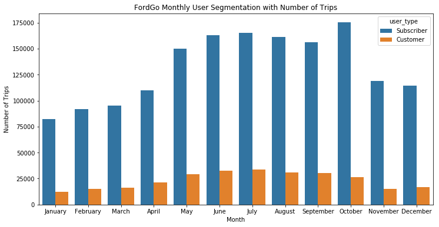

```python
plt.figure(figsize = [12, 6])
sns.countplot(data = df_fordgo_trips_2018_clean, x='start_month', hue='user_type')
plt.xlabel('Month')
plt.ylabel('Number of Trips')
plt.title('FordGo Monthly User Segmentation with Number of Trips');
```

## FordGo Weekdays User Segmentation with Number of Trips

> We can see that the subscribers commute more from Monday to Friday(may be because of office commutation) and the number of trips decreases on weekends whereas customers commute more on weekends might be because of party or entertainment purposes.

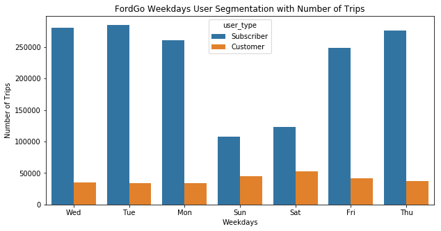

```python
plt.figure(figsize = [10, 5])
sns.countplot(data = df_fordgo_trips_2018_clean, x='start_weekday', hue='user_type')
plt.xlabel('Weekdays')
plt.ylabel('Number of Trips')
plt.title('FordGo Weekdays User Segmentation with Number of Trips');
```

## Average trip duration wrt user_type & weekdays

> We can see that the customers have the higher average trip duration as compared to the subscribers.

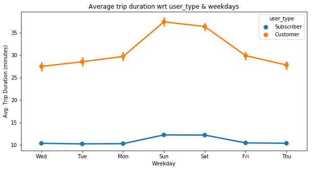

```python
plt.figure(figsize = [10, 5])
sns.pointplot(data=df_fordgo_trips_2018_clean, x='start_weekday', y='duration_min', hue='user_type')
plt.xlabel('Weekday')
plt.ylabel('Avg. Trip Duration (minutes)')
plt.title('Average trip duration wrt user_type & weekdays');
```

## Summary

> Once you're ready to finish your presentation, check your output by using nbconvert to export the notebook and set up a server for the slides. From the terminal or command line, use the following expression:

> > `jupyter nbconvert <file_name>.ipynb --to slides --post serve --template output_toggle`

> This should open a tab in your web browser where you can scroll through your presentation. Sub-slides can be accessed by pressing 'down' when viewing its parent slide. Make sure you remove all of the quote-formatted guide notes like this one before you finish your presentation!